# A Textual Analysis of Climate Agreements

Hannah Melville-Rea

05/05/2018

## Background

Usually when we examine treaties or agreements, we do so by reading through them. However, if we think of words as data, texts tell a very different story. This paper uses the programming language R to run a textual analysis of the Paris Agreement and Kyoto Protocol. By examining both climate agreements, I seek to highlight how the language that we use in climate change negotiations and agreements has changed over time.

**Sources**

The text of the two agreements were scraped from the internet for this analysis. The sources are:

Paris Agreement: http://cop21.okfnlabs.org/agreement/

Kyoto Protocol: https://unfccc.int/resource/docs/convkp/kpeng.html

## Process

The first step was to use the links to the agreements above, to scrape the text from the webpages and to read it into the programming language, R. Next I deleted unnecessary text before and after the body of the agreement that appeared on the webpages. The initial strings of text look like the following for the Paris Agreement:

```
## [1] "Preamble"
## [2] "The Parties to this Agreement"
## [3] "Being"
## [4] " Parties to the United Nations Framework Convention on Climate Change, hereinafter referred to as “the Convention”,"
## [5] "Pursuant"
## [6] " to the Durban Platform for Enhanced Action established by decision 1/CP.17 of the Conference of the Parties to the Convention at its seventeenth session,"
```

Next, I split the sentences into words, by writing a command that separates the text at every space. Further, I removed any commas, full stops, brackets and other punctuation or symbols. Finally, I changed all of the text to be in lower case. The beginning of the Paris Agreement after these steps looks as follows:

```
##  [1] "the"         "parties"     "to"          "this"        "agreement"
##  [6] "being"       "parties"     "to"          "the"         "united"
## [11] "nations"     "framework"   "convention"  "on"          "climate"
## [16] "change"      "hereinafter" "referred"
```

Once I had the agreement simplified into many elements of words, I added structure to the data by deviding the text into the various sections of the agreement (Eg. “Preamble”, “Article 1”, “Article 2”). I also added a numeric assignment, in which the Preamble was assigned as 0 and the articles as their numbers, to be able to use the structure in visualizations below. The following table shows the first few elements of the output once I had performed these steps:

| word | section | sec.no |
| --- | --- | --- |
| preamble | Preamble | 0 |
| the | Preamble | 0 |
| parties | Preamble | 0 |
| to | Preamble | 0 |
| this | Preamble | 0 |
| agreement | Preamble | 0 |
| being | Preamble | 0 |
| parties | Preamble | 0 |
| to | Preamble | 0 |
| the | Preamble | 0 |

However, most of the words in the text are connecting words that do not posses much meaning, such as “the”, “and”, “to”. In examining the most frequently appearing words, I did not want to focus on these words. Therefore, I utilized a package that was built for R with a list of “stop words”, or words that are not substantive, and I extracted these stop words so that the analysis would only be on substatial words. This process changed the order of the words, but we can see that the words that are left are substantive:

| word | section | sec.no |
| --- | --- | --- |
| agreed | Preamble | 0 |
| role | Preamble | 0 |
| play | Preamble | 0 |
| lead | Preamble | 0 |
| consumption | Preamble | 0 |
| patterns | Preamble | 0 |
| lifestyles | Preamble | 0 |
| addressing | Preamble | 0 |
| addressing | Preamble | 0 |
| legislations | Preamble | 0 |

## Frequent Words

The first test that I conducted on the climate agreements was to see what words appear most often in the text. Below, we see graphs that show us the most frequently appearing words, and how many times they appear in the text. If the word appeared at least 20 time, they are included in the visualizations below.

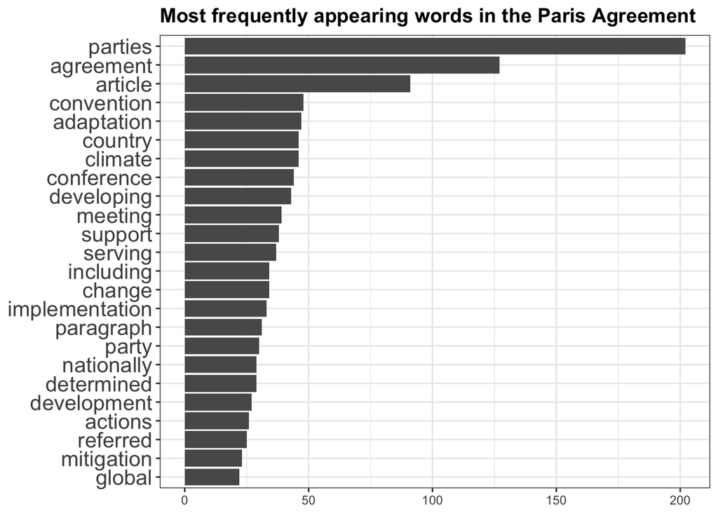

In relation to the Paris Agreement, we often mention “adaptation” and “mitigation”. Adaptation refers to shifting economies and societies to be able to deal with the impacts of climate change and to remain resilient, while mitigation refers to lessening the impacts of climate change through urgent reduction of green house gas emissions. It is interesting to note that the term “adaptation” appears in the text twice as many times as “mitigation”. This seems to indicate that a larger focus of the agreement is on adaptation, and that perhaps there is a sense of resignation towards our ability to prevent climate change.

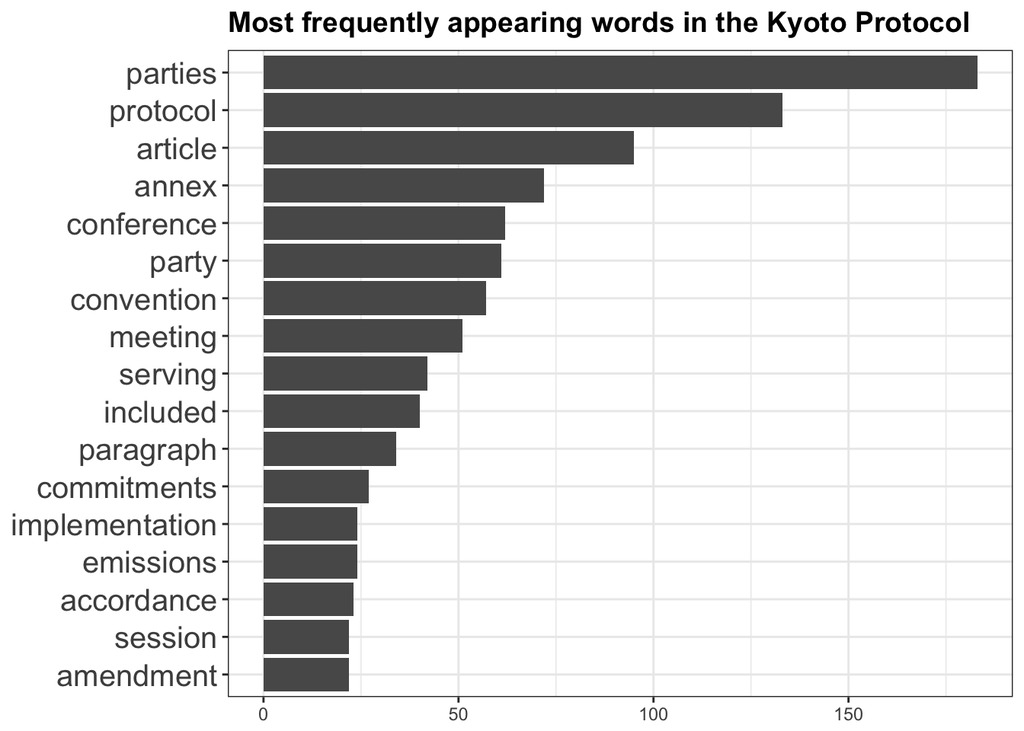

By comparing these two graphs, we can notice that the language we use in climate change agreements has changed. For example, the high use of “nationally” and “determined” highlights a key difference of the Paris Agreement, which is that nationally determined contributions (NDCs) were submitted by countries prior to the conference, outlining what each country would contribute. Further, this reflects a shift away from the annex country system (the term “annex” was repeated over 70 times in the Kyoto Protocol) in which developing and developed countries were separated in their efforts, and towards a inclusive system of contributing.As a result of moving away from the annex system, in the Paris Agreement we see that “developing” countries are singled out and terms such as “support”, “serving” and “development” are often used to highlight that the flow of support must still come from developed nations towards developing nations, and that while the developing world is expected to contribute, this also relies on support.

Similarly, we can see that the Kyoto Protocol has a narrower scope. The high frequency of the terms “emissions” and “commitments” indicates that the Kyoto Protocol is very focused on emission targets. Meanwhile, the Paris Agreement has a much wider approach to dealing with climate change.

Some language has remained consistent from 1997 to 2015. Most notably, “parties” has remained the most used term, as it refers to the subjects that will carry out the agreements. The very high use of this word indicates that the agreements are subject driven, giving signatories the agency to carry out the agreement.

# Sentiment Analysis

Sentiment analysis refers to examining the kinds of feelings that are attached to words. I used three different packages for my analysis, which are all essentially lists of many words with a value attached for whether the word has a positive or negative connotation. The packages differ to some extent. AFINN uses a point system, which not only assigned the word as positive or negative, but also assigns a value that reflects the degree to which the word is negative or positive. Bring et al.’s package merely assigns words as “negative” or “positive”. NRC assigns a whole range of feelings such as “surprise” and “fear” to the words, as well as “positive” and “negative”.

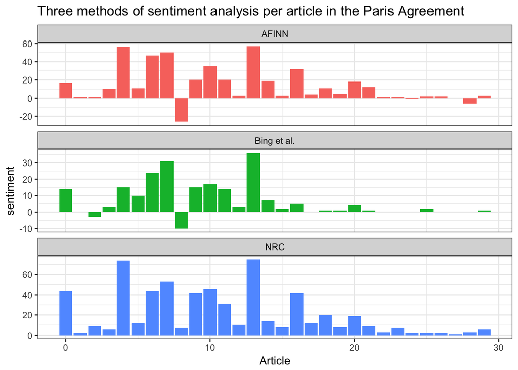

For the Paris Agreement, Article 8 seems to contain the most negative words. This makes sense because Article 8 focuses on “loss and damage”. Meanwhile, Article 4 (which focuses on NDCs) and Article 13 (which focuses on capacity building) contains many positive words.

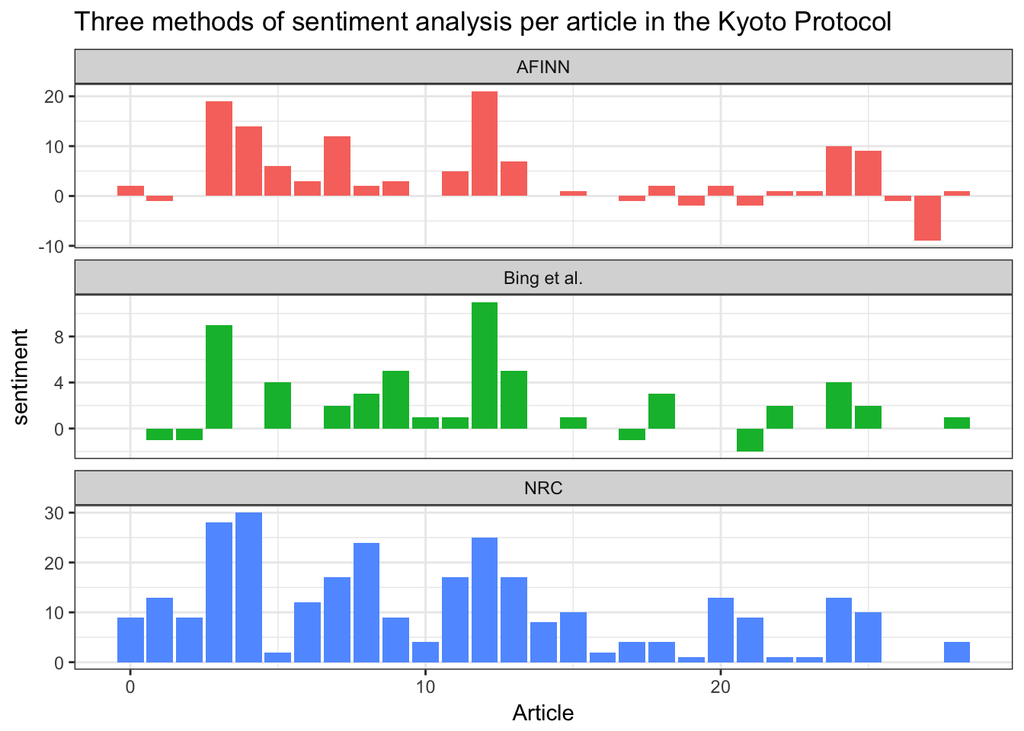

In the Kyoto Protocol, the most negative article seems to be Article 27 which specifies the procedure of withdrawing from the agreement. Meanwhile, Article 3 (Annex I country commitments) and Article 12 (outlining the clean development mechanism) possess the most positive words. It is worth noting however, that these two articles are also among the longest articles, and thereby have more opportunity to contain many positive words.

In general, there seems to be many more words with positive connotations used in both agreements than words with negative connotations. This shows that the language used in climate agreements, despite dealing with a serious topic, still package the actions that need to be taken as positive efforts. In other words, less time is taken on outlining the risks and impacts of environmental damage and climate change, and the focus is solely on the actions that will be taken.

## Positive and Negative Words

### Positive words

**Paris Agreement**

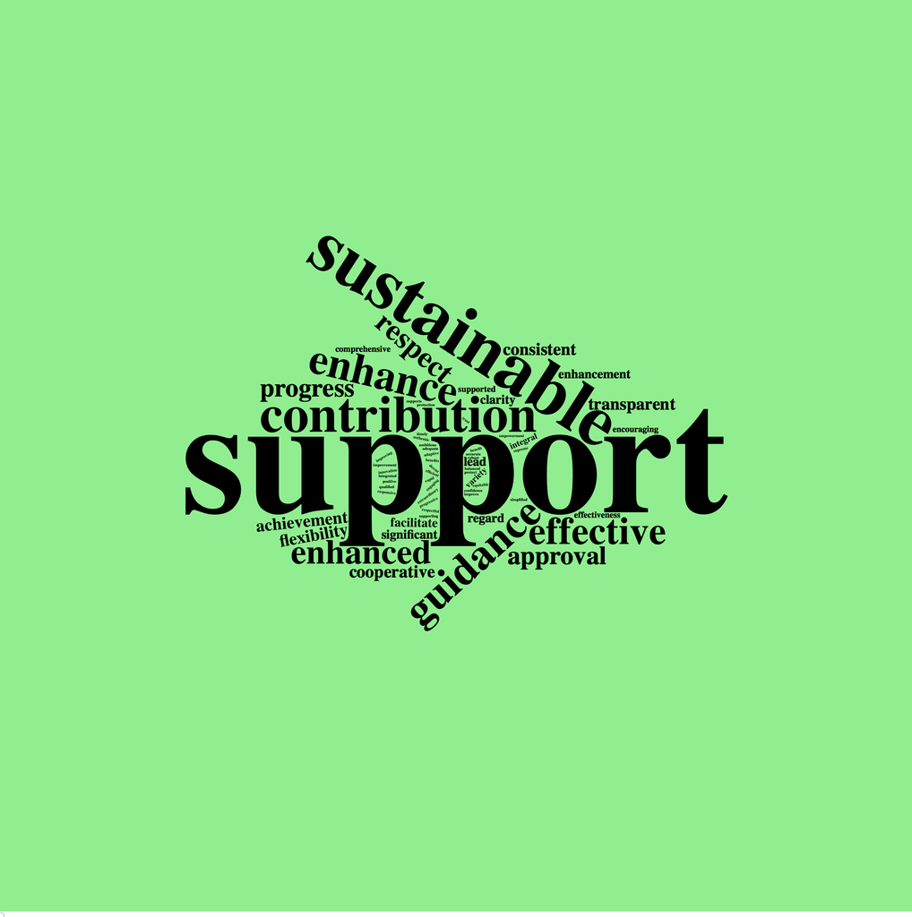

**Kyoto Protocol**

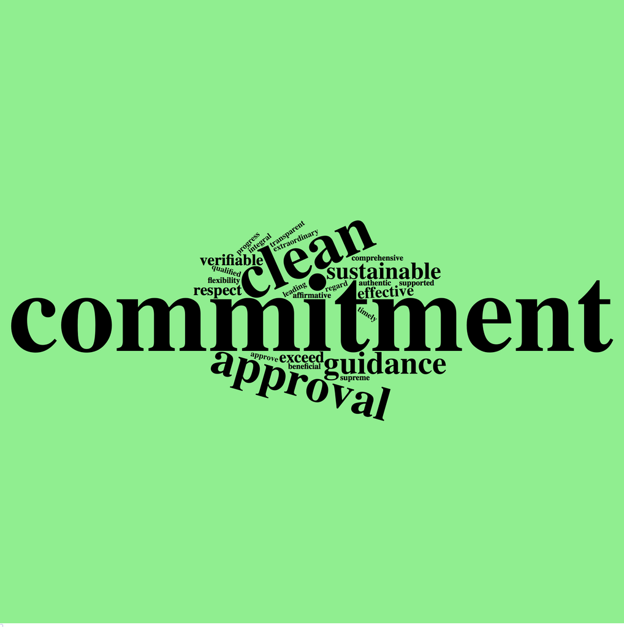

By examining the differences in the positive words used in the Paris Agreement versus the Kyoto Protocol, we can see that there has been a shift from an approach where developed countries make emission commitments towards a more collaborative approach that supports developing nations while expecting all nations to make contributions. Our discourse for describing sustainability has also changed over time. For example, the word “clean” despite having been a frequently used term in the Kyoto Protocol has been eradicated from the Paris Agreement.

### Negative words

**Paris Agreement**

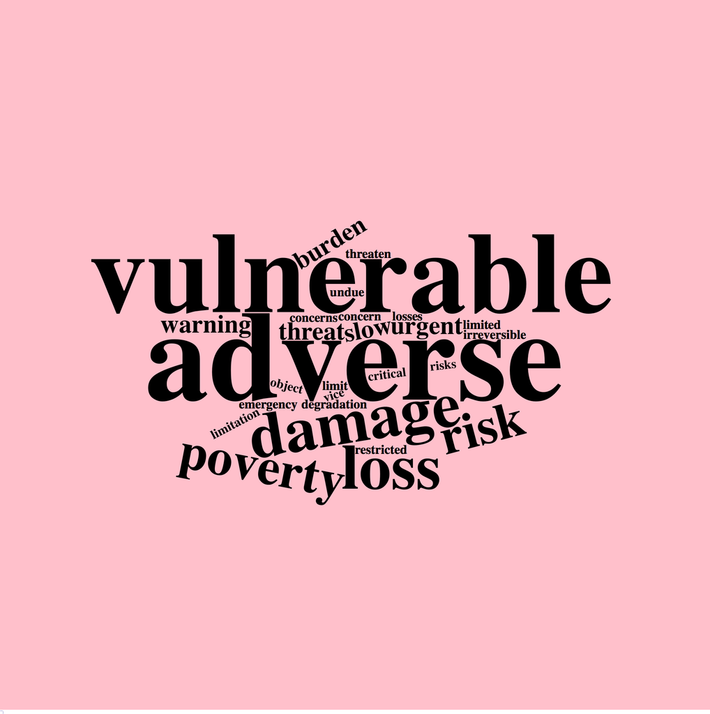

**Kyoto Protocol**

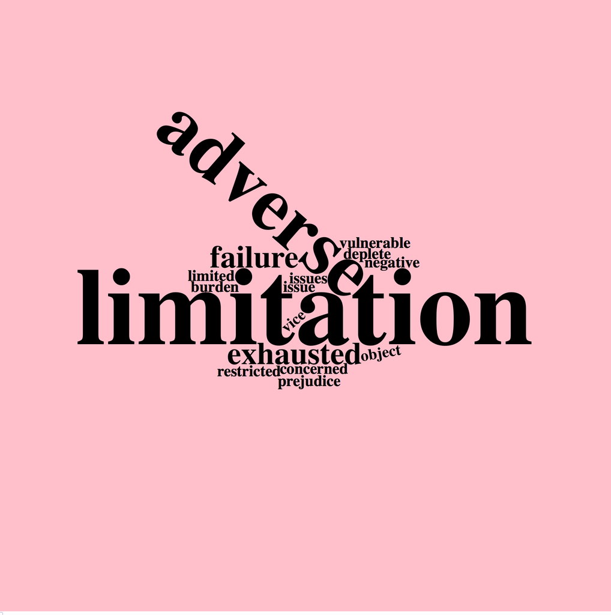

The negative language used in the climate agreements have become much more human centric in the Paris Agreement. For example, “vulnerable”, “loss”, “poverty” all reflect how climate change is now seen as a human problem, that will directly affect people. In contrast, the Kyoto Protocol seems to focus on the depletion of resources and the adverse impacts this may have without relating it to the human perspective.

## Concluding remarks

While examining the Paris Agreement and Kyoto Protocol through this kind of systematic lens does not provide the full picture of the agreements, it reveals aspects of the agreement that we may have missed otherwise. Further, it has allowed us to see how our discourse of climate change has changed by narrowing in on words that contain meaning and are repeated often.